# K-means Clustering

Bradley Warner

May 14, 2019

# Objectives

1. Understand clustering in the greater scope of unsupervised learning.
2. Understand and explain distance metrics and scaling.
3. Explain K-means clustering algorithm and its parameters.
4. Use K-means clustering in R.

# Unsupervised Learning

### Question

What is unsupervised learning in comparison to supervised learning?

It is more challenging because it is hard to tune and validate models.

Examples:  
1. Marketing segmentation  
2. Gene grouping  
3. Dimension reduction in predictive modeling  
4. Language translation models in deep learning  
5. EDA  
6. [Cyber profiling](https://dzone.com/articles/10-interesting-use-cases-for-the-k-means-algorithm)

### Question

For which of the following would clustering likely be appropriate:

1. Predicting if a user will click on an AD
2. Identifying stocks that follow similar trading patterns
3. Modeling 30-day mortality post-surgery
4. Grouping response to customer survey
5. Identifying similar players for a fantasy league draft

# K-means Ideas

K-means is a partitioning method that finds subgroups that are similar. We must consider:

1. How many subgroups.
2. What does similar mean.

## Distance

In this example, we are creating two points, consider them to be players on a field.

```r
two_players<-data.frame(x=c(5,15),y=c(4,10))
```

Load the libraries.

```r
library(tidyverse)
```

Plot the two players and then calculate their Euclidean distance.

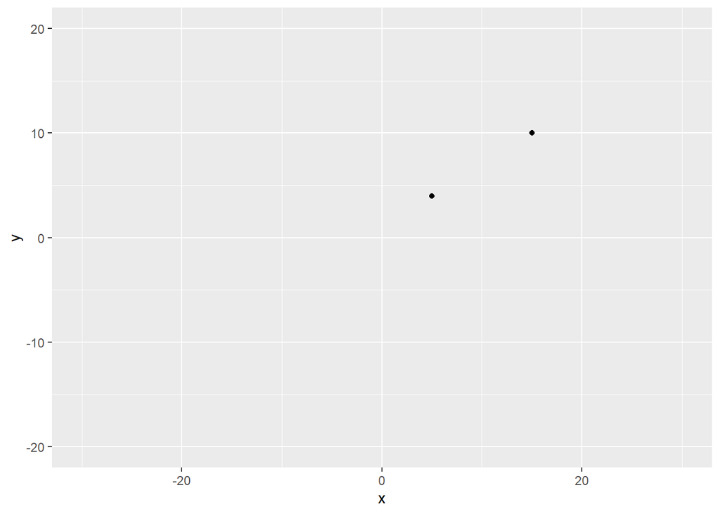

```r
# Plot the positions of the players
ggplot(two_players, aes(x = x, y = y)) +
  geom_point() +
  # Assuming a 40x60 field
  lims(x = c(-30,30), y = c(-20, 20))
```

The distance between them is:

```r
# Split the players data frame into two observations
player1 <- two_players[1, ]
player2 <- two_players[2, ]

# Calculate and print their distance using the Euclidean Distance formula
player_distance <- sqrt( (player1$x - player2$x)^2 + (player1$y - player2$y)^2 )
player_distance
```

```
## [1] 11.6619
```

There is a built in function for this called dist.

```r
# Calculate the Distance Between two_players
dist_two_players <- dist(two_players)
dist_two_players
```

```
##         1
## 2 11.6619
```

Let’s add another player and find the distance.

```r
three_players <- rbind(c(0,20),two_players)
three_players
```

| x | y |
| --- | --- |
| 0 | 20 |
| 5 | 4 |
| 15 | 10 |

The distance between them pairwise is:

```r
# Calculate the Distance Between two_players
dist_three_players <- dist(three_players)
dist_three_players
```

```
##          1        2
## 2 16.76305
## 3 18.02776 11.66190
```

Let’s use the `factoextra` package to look at distance.

```r
library(factoextra)
```

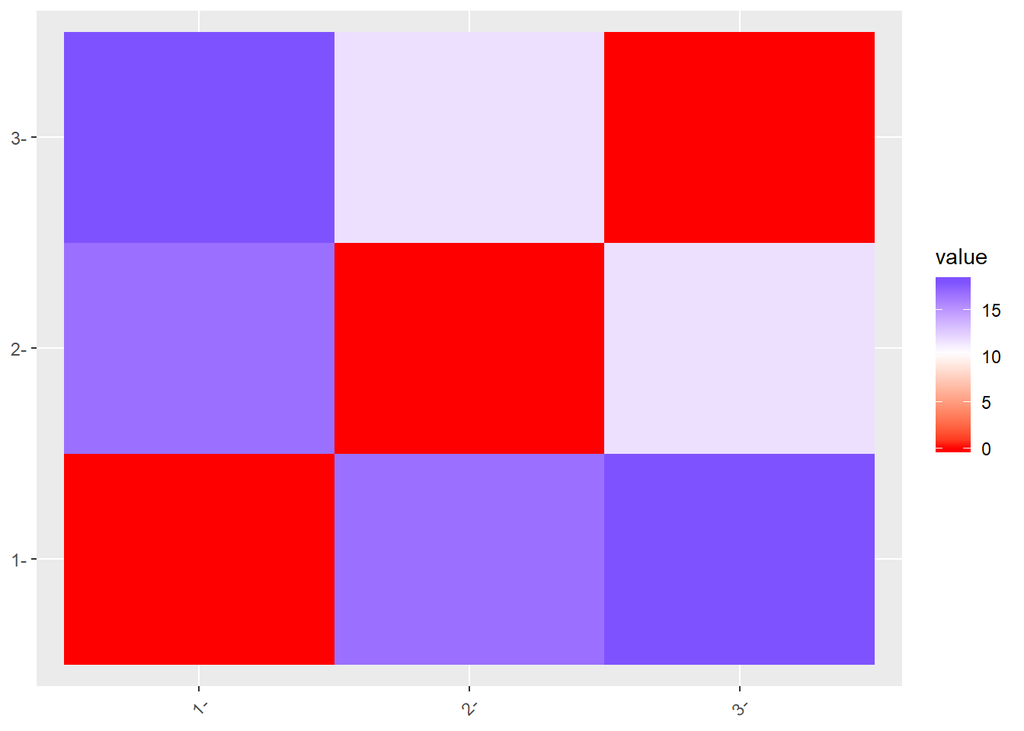

```r
fviz_dist(get_dist(three_players))
```

Let’s add another player.

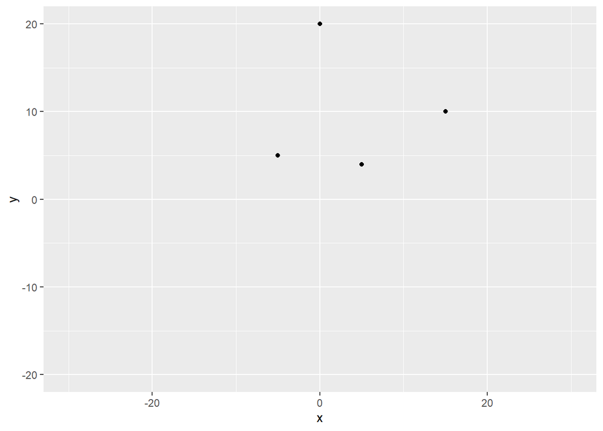

```r
four_players<-rbind(c(-5,5),three_players)
# Plot the positions of the players
ggplot(four_players, aes(x = x, y = y)) +
  geom_point() +
  # Assuming a 40x60 field
  lims(x = c(-30,30), y = c(-20, 20))
```

```r
get_dist(four_players)
```

```
##          1        2        3
## 2 15.81139
## 3 10.04988 16.76305
## 4 20.61553 18.02776 11.66190
```

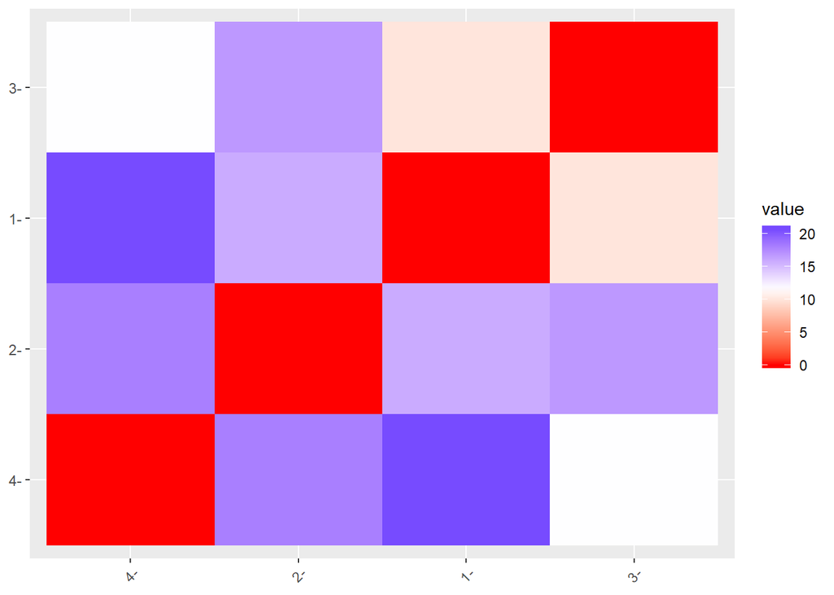

```r
fviz_dist(get_dist(four_players))
```

## Scaling

What happens if our variables have different scales. Let’s use the trees data. To get more information on the data type:

```
?trees
```

```r
three_trees <- trees[c(1,2,4),1:2]
three_trees
```

|  | Girth | Height |
| --- | --- | --- |
| 1 | 8.3 | 70 |
| 2 | 8.6 | 65 |
| 4 | 10.5 | 72 |

Notice that height is a much larger scale than girth and will dominate the distance metric.

```r
get_dist(three_trees)
```

```
##          1        2
## 2 5.008992
## 4 2.973214 7.253275
```

Points 1 and 4 are the closest in terms of height but that is because it is a much larger scale than girth.

Scaling will put all variables on same scale.

```r
get_dist(three_trees,stand=TRUE)
```

```
##          1        2
## 2 1.409365
## 4 1.925659 2.511082
```

Notice that points 1 and 2 are now the closest.

### Question

Should we scale if we are working with height, weight, and body fat?

## Distance for Categorical Variables

What about categorical variables?

Let’s makeup some data.

```r
job_survey <- data.frame(job_satisfaction=c("Low","Low","Hi","Low","Mid"),
                         is_happy = c("No","No","Yes","No","No"))
job_survey
```

| job_satisfaction | is_happy |
| --- | --- |
| Low | No |
| Low | No |
| Hi | Yes |
| Low | No |
| Mid | No |

Load a new library.

```r
library(dummies)
# Dummify the Survey Data
dummy_survey <- dummy.data.frame(job_survey)
# Calculate the Distance
dist_survey <- get_dist(dummy_survey,method="binary")

# Print the Original Data
job_survey
```

| job_satisfaction | is_happy |
| --- | --- |
| Low | No |
| Low | No |
| Hi | Yes |
| Low | No |
| Mid | No |

```r
dummy_survey
```

|  | job_satisfactionHi | job_satisfactionLow | job_satisfactionMid | is_happyNo | is_happyYes |
| --- | --- | --- | --- | --- | --- |
| 1 | 0 | 1 | 0 | 1 | 0 |
| 2 | 0 | 1 | 0 | 1 | 0 |
| 3 | 1 | 0 | 0 | 0 | 1 |
| 4 | 0 | 1 | 0 | 1 | 0 |
| 5 | 0 | 0 | 1 | 1 | 0 |

One hot encoding in deep learning.

```r
# Print the Distance Matrix
dist_survey
```

```
##           1         2         3         4
## 2 0.0000000
## 3 1.0000000 1.0000000
## 4 0.0000000 0.0000000 1.0000000
## 5 0.6666667 0.6666667 1.0000000 0.6666667
```

The binary metric is Jaccard distance which is 1 minus the intersection over the union.

If we have mixed, then we could use the Gower metric with the daisy function in the cluster package.

We are ready to learn about the algorithm for K-means.

# K-means Algorithm

We want to develop an insight into the algorithm. We will use the simple players data to motivate the algorithm.

## Setup

Get data for the two teams.

```r
lineup <- readRDS("lineup.rds")
lineup
```

| x | y |
| --- | --- |
| -1 | 1 |
| -2 | -3 |
| 8 | 6 |
| 7 | -8 |
| -12 | 8 |
| -15 | 0 |
| -13 | -10 |
| 15 | 16 |
| 21 | 2 |
| 12 | -15 |

[output cut: 2 more lines]

Plot the data.

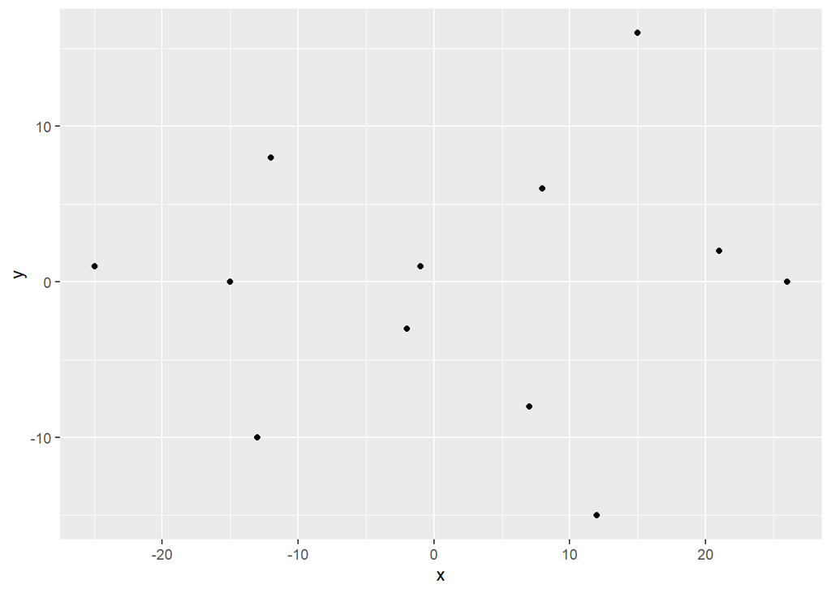

```r
ggplot(lineup, aes(x = x, y = y)) +
  geom_point()
```

## Metric

In this problem we know that there are two teams so we have two clusters. In most problems we will not know the clusters. To find the clusters we need a metric. We minimize the within-cluster variation.

$${1 \over |C_k|} \sum_{i, i' \in C_k} \sum_{j=1}^{p} (x_{ij} - x_{i'j})^{2}$$
by expanding around the cluster mean, this is equivalent to

$$2 \sum_{ i \in C_k} \sum_{j=1}^{p} (x_{ij} - \bar{x}_{kj})^{2}$$

## Pseudo code

```
Pick number of cluster

1. Randomly assign each point to a cluster or randomly pick centroid
2. Iterate until cluster assignments stop changing
  a) Find centroids, mean of the features
  b) Assign each observation to cluster with closet centroid
```

## One Iteration

Let take a couple of steps manually through the algorithm

```r
set.seed(2019)
cluster <- sample(c(1,2),12,replace=TRUE)
```

Plot the positions of the players and color them using their cluster

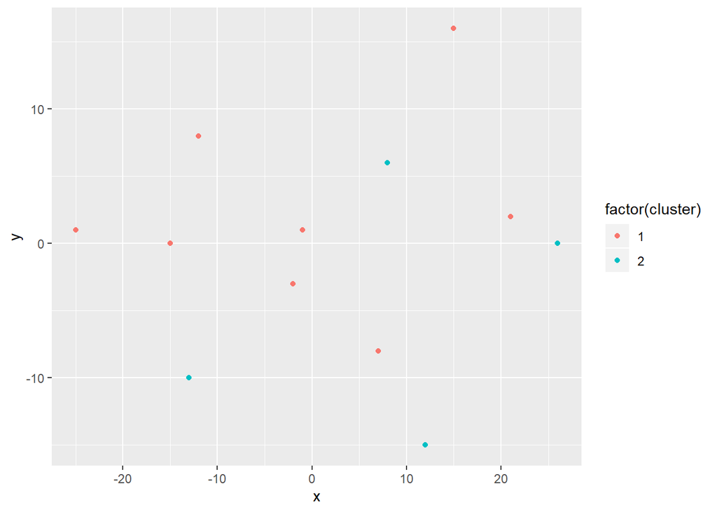

```r
ggplot(lineup, aes(x = x, y = y, color = factor(cluster))) +
  geom_point()
```

Find the centroids.

```r
map_dbl(lineup[cluster==1,],mean)
```

```
##      x      y
## -1.500  2.125
```

```r
centroids <- cbind(lineup,cluster) %>% group_by(cluster) %>%
  summarise(x=mean(x),y=mean(y))
centroids
```

| cluster | x | y |
| --- | --- | --- |
| 1 | -1.50 | 2.125 |
| 2 | 8.25 | -4.750 |

```r
dist_new <- as.matrix(get_dist(rbind(centroids[,-1],lineup)))[-(1:2),1:2]
dist_new
```

```
##            1         2
## 3   1.231107 10.891510
## 4   5.149332 10.398317
## 5  10.259904 10.752907
## 6  13.219895  3.482097
## 7  12.031859 23.929584
## 8  13.666222 23.730255
## 9  16.711242 21.888924
## 10 21.558424 21.820289
## 11 22.500347 14.426538
## 12 21.806321 10.914440
## 13 23.526913 33.743518
## 14 27.581980 18.374575
```

```r
cluster <- (dist_new[,1]>dist_new[,2]) +1
cluster
```

```
##  3  4  5  6  7  8  9 10 11 12 13 14
##  1  1  1  2  1  1  1  1  2  2  1  2
```

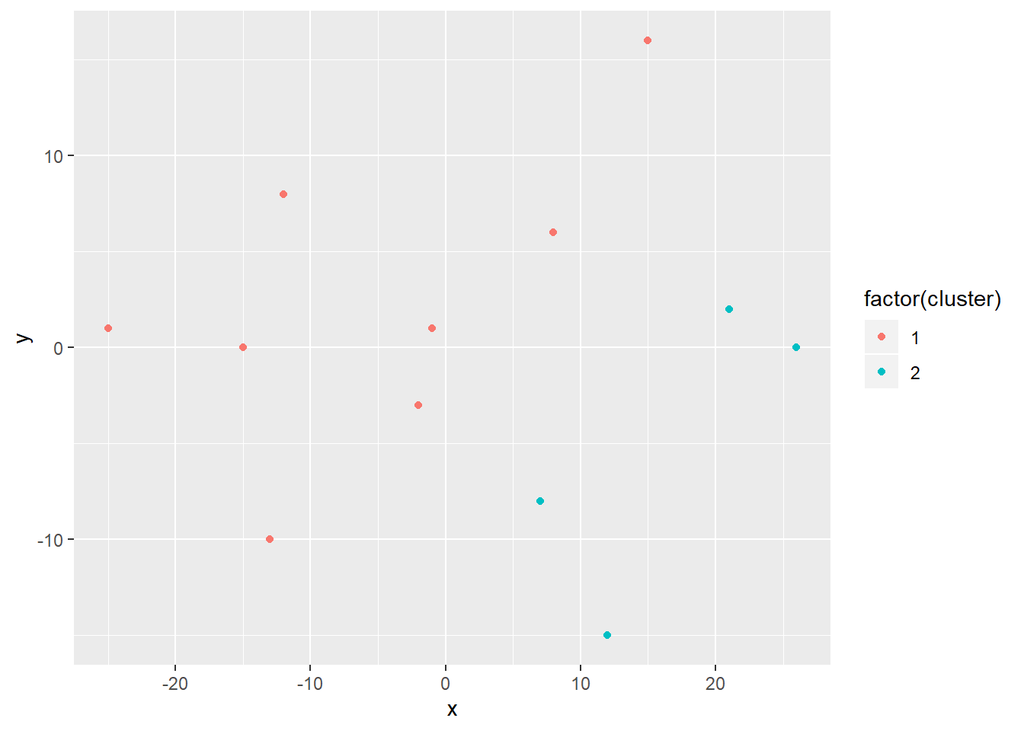

```r
ggplot(lineup, aes(x = x, y = y, color = factor(cluster))) +
  geom_point()
```

# K-means in R

We will now build our first K-means model using the function in R. We will use default parameters at first.

## Build First K-means model in R

```r
model_km2 <- kmeans(lineup, centers = 2)
```

```r
names(model_km2)
```

```
## [1] "cluster"      "centers"      "totss"        "withinss"
## [5] "tot.withinss" "betweenss"    "size"         "iter"
## [9] "ifault"
```

Extract the cluster assignment vector from the K-means model

```r
clust_km2 <- model_km2$cluster
clust_km2
```

```
##  [1] 2 2 1 1 2 2 2 1 1 1 2 1
```

Create a new data frame appending the cluster assignment.

```r
lineup_km2 <- mutate(lineup, cluster = clust_km2)
lineup_km2
```

| x | y | cluster |
| --- | --- | --- |
| -1 | 1 | 2 |
| -2 | -3 | 2 |
| 8 | 6 | 1 |
| 7 | -8 | 1 |
| -12 | 8 | 2 |
| -15 | 0 | 2 |
| -13 | -10 | 2 |
| 15 | 16 | 1 |
| 21 | 2 | 1 |
| 12 | -15 | 1 |

[output cut: 2 more lines]

Plot the positions of the players and color them using their cluster

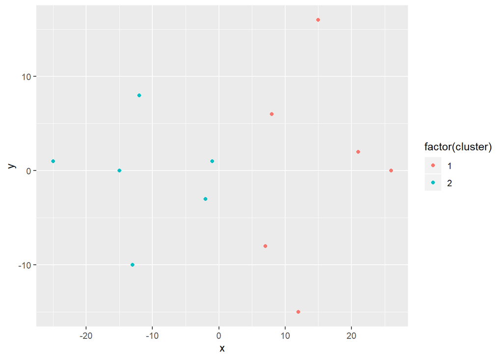

```r
ggplot(lineup_km2, aes(x = x, y = y, color = factor(cluster))) +
  geom_point()
```

## Visualize the Results

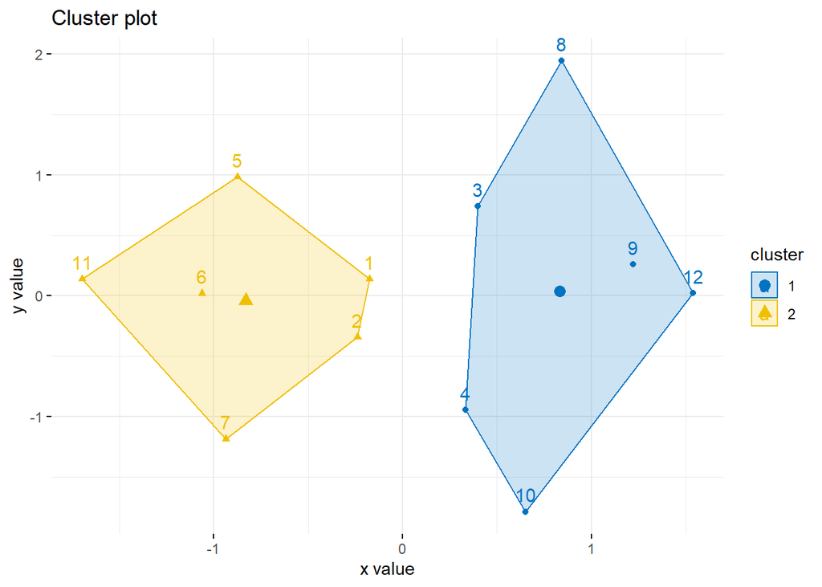

```r
fviz_cluster(model_km2, data = lineup, palette = "jco",
             ggtheme = theme_minimal())
```

## Change Number of Clusters

Since we knew beforehand that there were two teams we made this problems easier. Often we do not know how many clusters. Before we attack this problem, let’s see what happens if we use three clusters.

Build the K-means model.

```r
# Build a kmeans model
model_km3 <- kmeans(lineup,centers=3)

# Extract the cluster assignment vector from the kmeans model
clust_km3 <- model_km3$cluster

# Create a new data frame appending the cluster assignment
lineup_km3 <- mutate(lineup,cluster = clust_km3)
```

Now let’s plot the results.

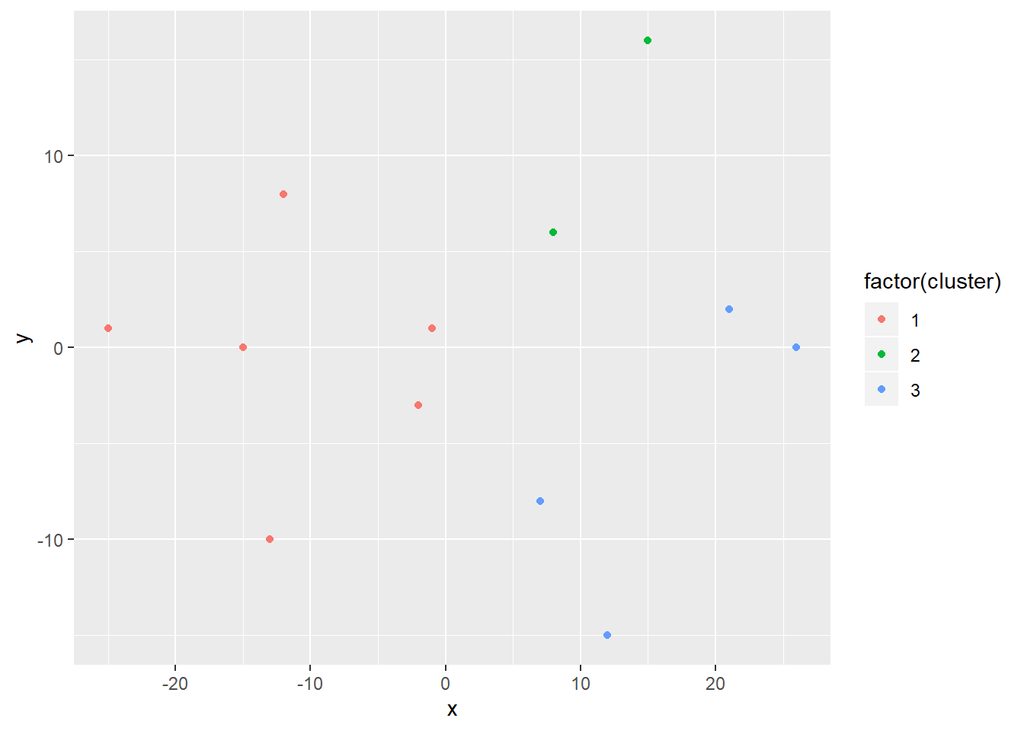

```r
# Plot the positions of the players and color them using their cluster
ggplot(lineup_km3, aes(x = x, y = y, color = factor(cluster))) +
  geom_point()
```

We will look at the cluster plots.

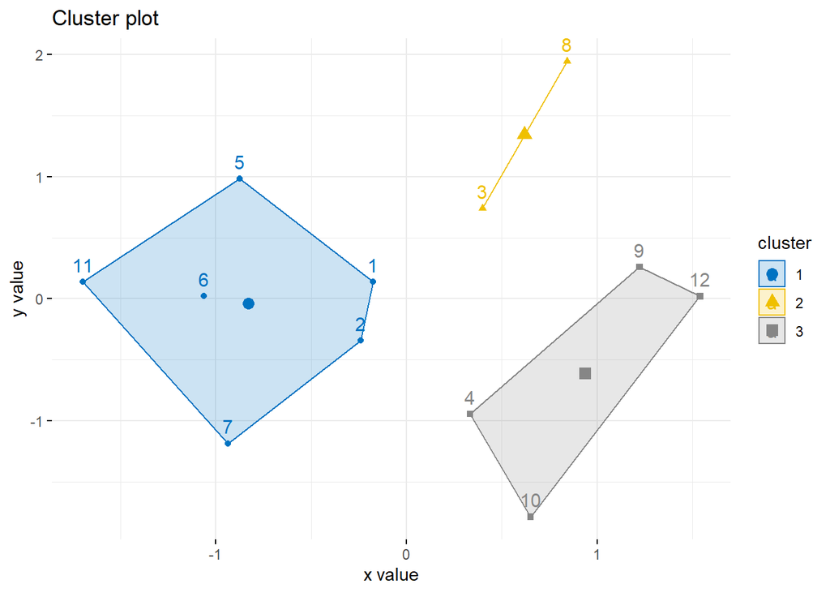

```r
fviz_cluster(model_km3, data = lineup, palette = "jco",
             ggtheme = theme_minimal())
```

The algorithm let’s us use any number of clusters from 2 up to the number of data points.

## Starting Seed

Let’s run the same model again but since the seed is different, we may get a different model.

```r
set.seed(11)
# Build a kmeans model
model_km3a <- kmeans(lineup,centers=3)

# Extract the cluster assignment vector from the kmeans model
clust_km3a <- model_km3a$cluster

# Create a new data frame appending the cluster assignment
lineup_km3a <- mutate(lineup,cluster = clust_km3a)
```

```r
model_km3
```

```
## K-means clustering with 3 clusters of sizes 6, 2, 4
##
## Cluster means:
##           x     y
## 1 -11.33333 -0.50
## 2  11.50000 11.00
## 3  16.50000 -5.25
##
## Clustering vector:
##  [1] 1 1 2 3 1 1 1 2 3 3 1 3
##
## Within cluster sum of squares by cluster:
## [1] 570.8333  74.5000 403.7500
##  (between_SS / total_SS =  69.9 %)
##
## Available components:
##
## [1] "cluster"      "centers"      "totss"        "withinss"
## [5] "tot.withinss" "betweenss"    "size"         "iter"
## [9] "ifault"
```

Now let’s plot the results.

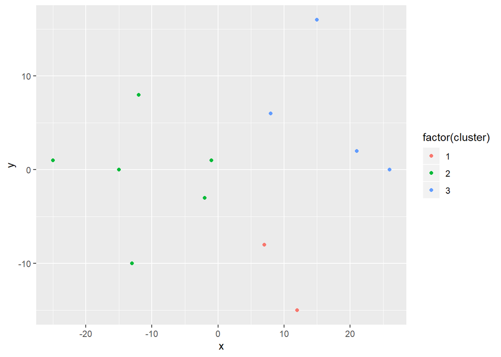

```r
# Plot the positions of the players and color them using their cluster
ggplot(lineup_km3a, aes(x = x, y = y, color = factor(cluster))) +
  geom_point()
```

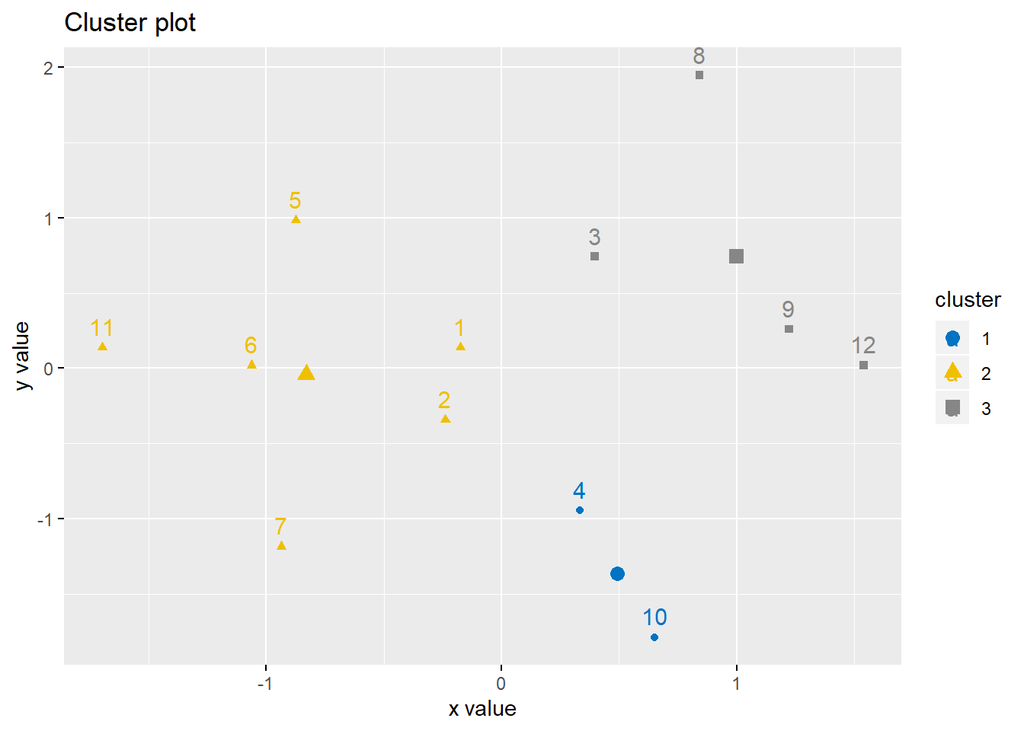

```r
fviz_cluster(model_km3a, data = lineup, palette = "jco", ellipse = FALSE,
             ggtheme = theme_gray())
```

## Issues to Consider

The model is sensitive to the starting position of clusters and also to the number of clusters.

Thus we need:  
1 Run K-means for different random seeds with fixed number of clusters  
2 Find method to determine the number of clusters

## Running Multiple Models

To address the first issue, R lets us use run multiple models with the `nstart` option and will return the single best model. What is best?

```r
# Build a kmeans model
model_km3_best <- kmeans(lineup,centers=3,nstart=25)

# Extract the cluster assignment vector from the kmeans model
clust_km3_best <- model_km3_best$cluster

# Create a new data frame appending the cluster assignment
lineup_km3_best <- mutate(lineup,cluster = clust_km3_best)
```

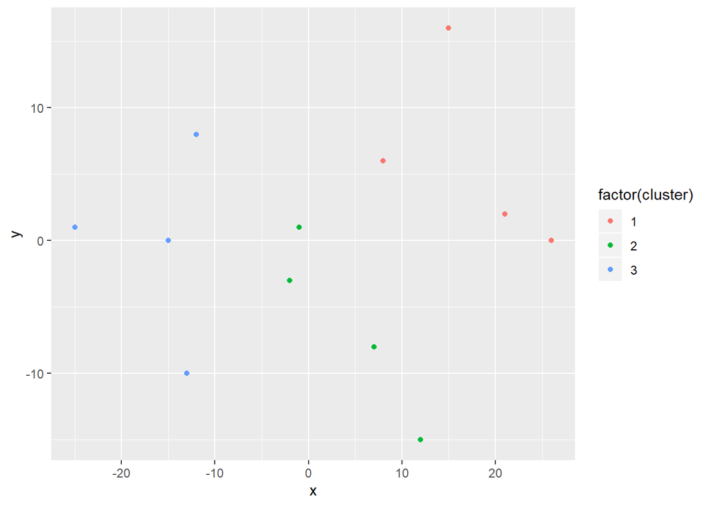

```r
# Plot the positions of the players and color them using their cluster
ggplot(lineup_km3_best, aes(x = x, y = y, color = factor(cluster))) +
  geom_point()
```

```r
c(model_km3a$tot.withinss,model_km3_best$tot.withinss)
```

```
## [1] 940.8333 881.2500
```

## Elbow Method

To determine the number of clusters we can plot the total within sum of squares versus clusters and look for a diminishing return. This is called a scree plot. We will use a mapping function to perform this.

First create the mapping.

```r
# Use map_dbl to run many models with varying value of k (centers)
tot_withinss <- map_dbl(1:10,  function(k){
  model <- kmeans(x = lineup, centers = k,nstart=25)
  model$tot.withinss
})
```

Now merge into a data frame.

```r
# Generate a data frame containing both k and tot_withinss
elbow_df <- data.frame(
  k = 1:10 ,
  tot_withinss = tot_withinss
)
head(elbow_df)
```

|  | k | tot_withinss |
| --- | --- | --- |
| 1 | 1 | 3489.9167 |
| 2 | 2 | 1434.5000 |
| 3 | 3 | 881.2500 |
| 4 | 4 | 622.5000 |
| 5 | 5 | 406.0000 |
| 6 | 6 | 265.1667 |

Let’s plot the within sum of squares as a function of the number of clusters.

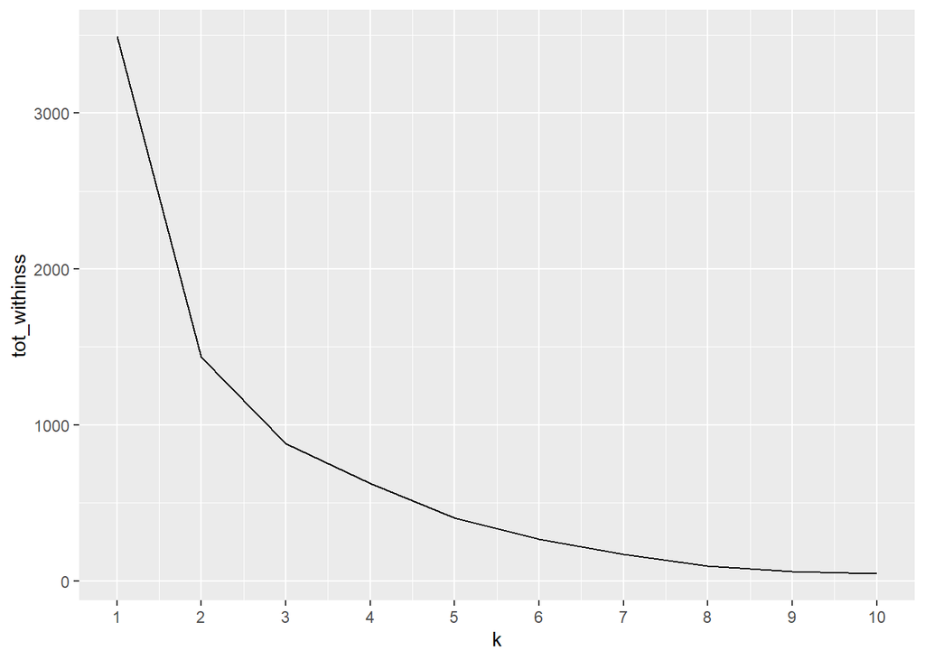

```r
# Plot the elbow plot
ggplot(elbow_df, aes(x = k, y = tot_withinss)) +
  geom_line() +
  scale_x_continuous(breaks = 1:10)
```

Note: Determining an elbow, or knee, in the plot has always been difficult for me. This methods is lacking in a clear guidance. I would think 2 or 3 are where the knee occurs but it is not obvious.

Instead of writing all this code, we could use the following code.

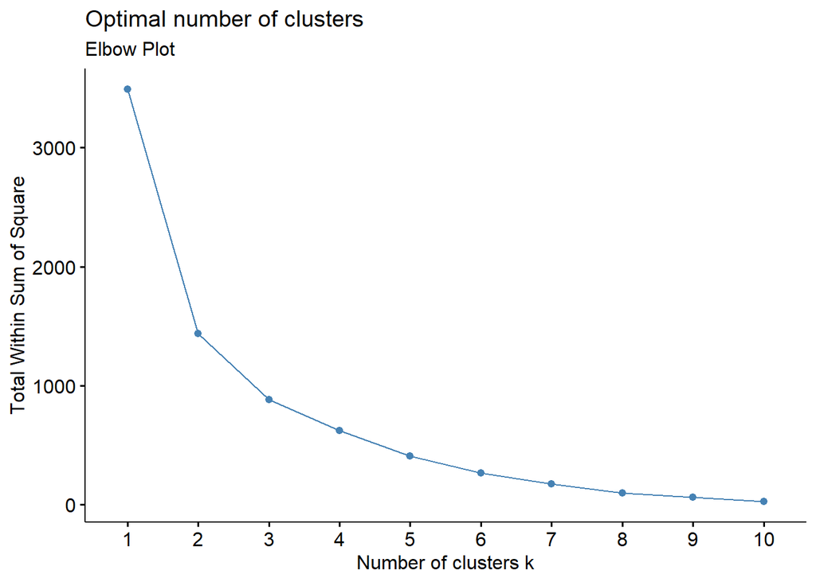

```r
fviz_nbclust(lineup, kmeans,nstart=25, method = "wss") +
  labs(subtitle = "Elbow Plot")
```

## Other Methods to Determine Numbers of Clusters

There are other methods to determine the number of clusters, [datanovia](https://www.datanovia.com/en/lessons/determining-the-optimal-number-of-clusters-3-must-know-methods/) has a great tutorial.

The silhouette method compares the average distance of each point in a cluster to the average distance in the closet neighbor. For a particular number of cluster we can find the average silhouette distance. The closer the value to 1 the better.

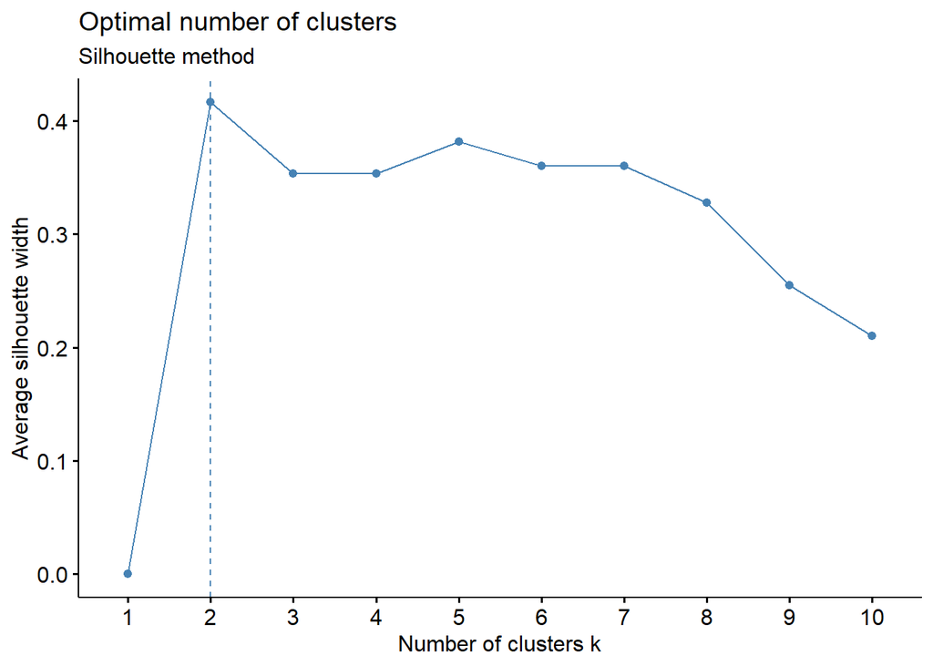

```r
fviz_nbclust(lineup, kmeans, nstart=25, method = "silhouette")+
  labs(subtitle = "Silhouette method")
```

This is much more satisfying.

## More Insight on Sihouette

```r
library(cluster)
```

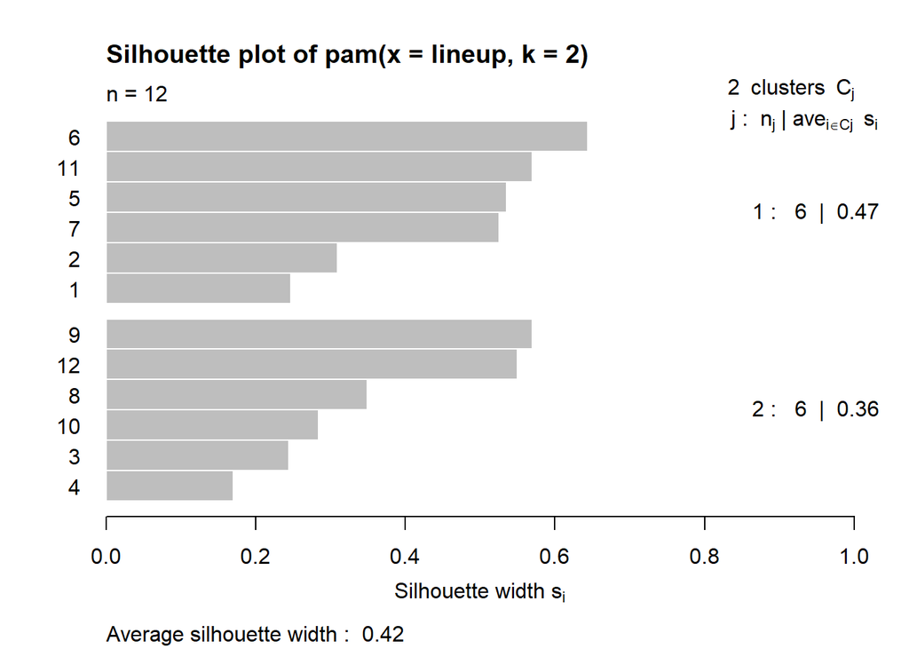

```r
# Generate a k-means model using the pam() function with a k = 2
pam_k2 <- pam(lineup, k = 2)

# Plot the silhouette visual for the pam_k2 model
plot(silhouette(pam_k2))
```

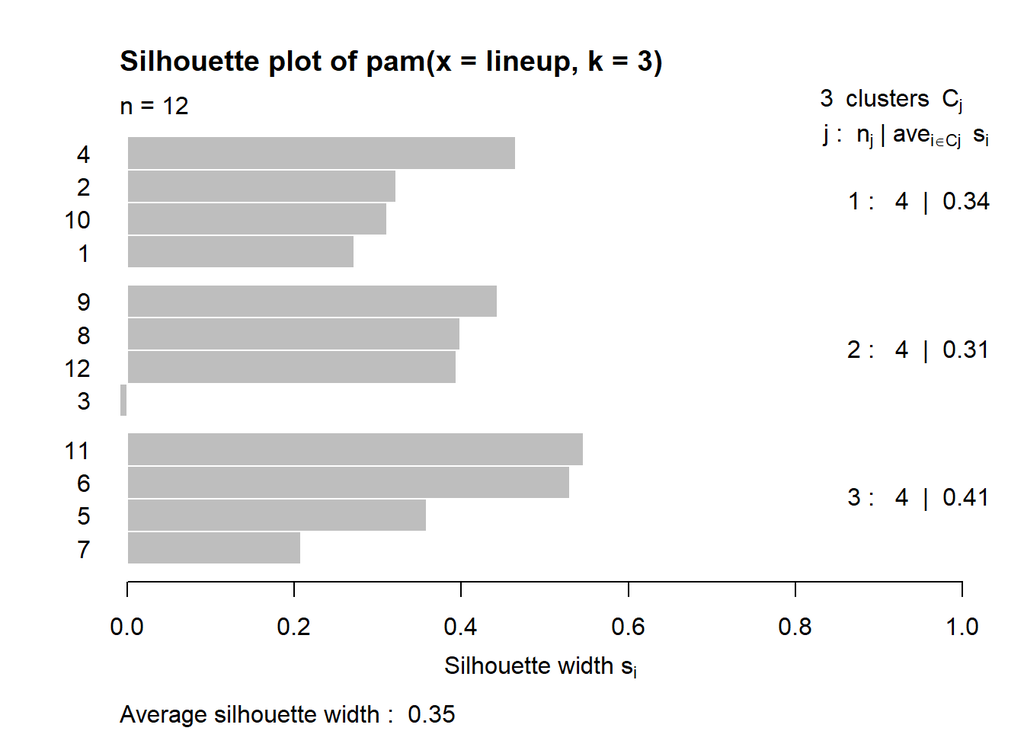

```r
# Generate a k-means model using the pam() function with a k = 3
pam_k3 <- pam(lineup,k=3)

# Plot the silhouette visual for the pam_k3 model
plot(silhouette(pam_k3))
```

Another method is using the gap statistic. Note there are over 30 indices that could be used and the package NbClust uses them all.

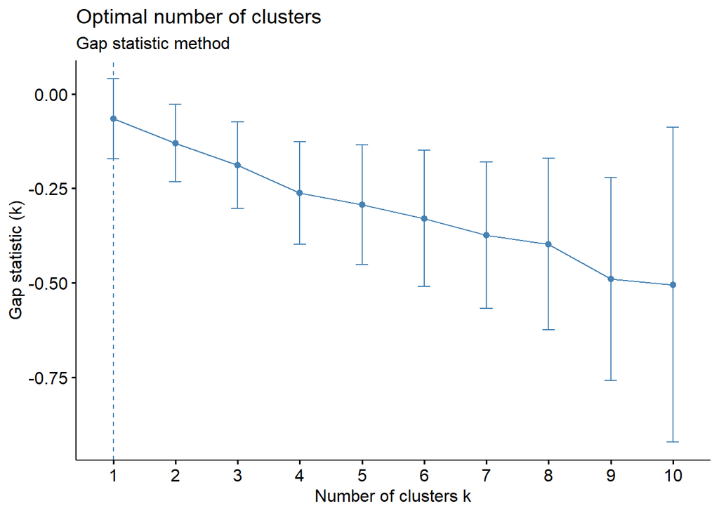

```r
set.seed(511)
fviz_nbclust(lineup, kmeans, nstart = 25,  method = "gap_stat", nboot = 50)+
  labs(subtitle = "Gap statistic method")
```

```r
library(NbClust)
```

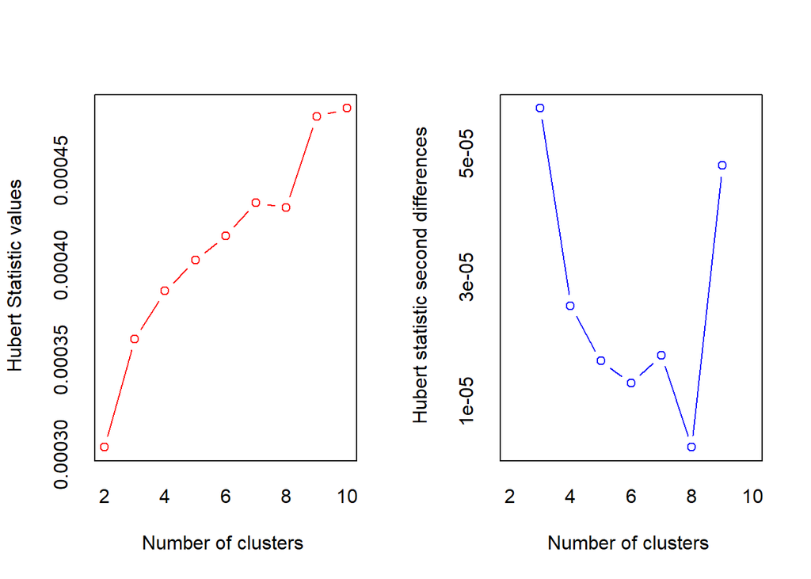

```
## *** : The Hubert index is a graphical method of determining the number of clusters.
##                 In the plot of Hubert index, we seek a significant knee that corresponds to a
##                 significant increase of the value of the measure i.e the significant peak in Hubert
##                 index second differences plot.
##
```

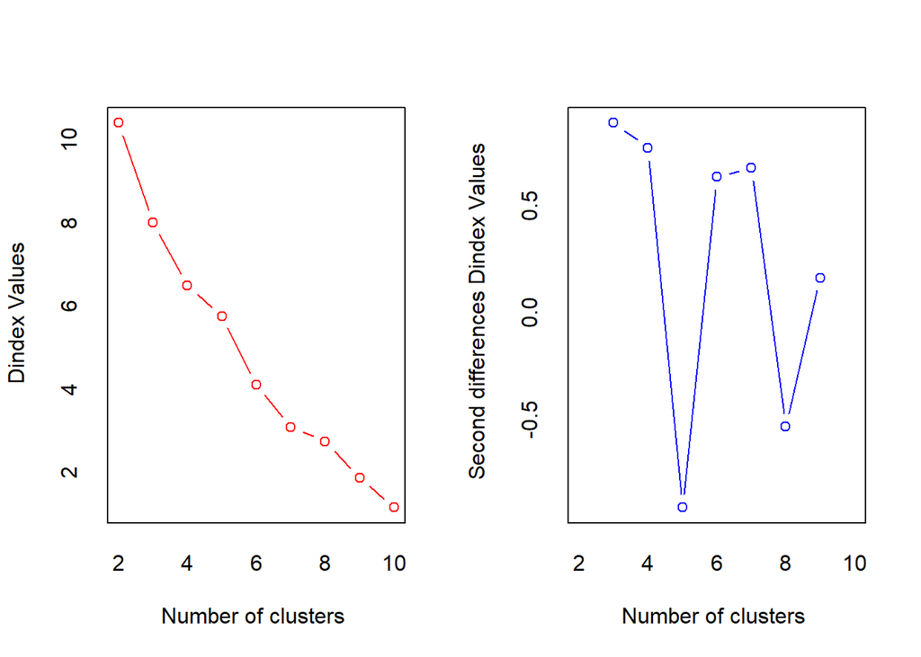

```
## *** : The D index is a graphical method of determining the number of clusters.
##                 In the plot of D index, we seek a significant knee (the significant peak in Dindex
##                 second differences plot) that corresponds to a significant increase of the value of
##                 the measure.
##
## * Among all indices:
## * 6 proposed 2 as the best number of clusters
## * 4 proposed 3 as the best number of clusters
## * 1 proposed 4 as the best number of clusters
## * 1 proposed 5 as the best number of clusters
## * 4 proposed 6 as the best number of clusters
## * 1 proposed 7 as the best number of clusters
## * 6 proposed 10 as the best number of clusters
##
##                    ***** Conclusion *****
##
## * According to the majority rule, the best number of clusters is  2
##
##
```

```
##                    Length Class  Mode
## All.index          234    -none- numeric
## All.CriticalValues  27    -none- numeric
## Best.nc             52    -none- numeric
## Best.partition      12    -none- numeric
```

```r
summary(NbClust(lineup,method='kmeans',max.nc = 10))
```

Too few data. It is clear that selecting the number of clusters is not trivial.

## Weaknesses

K-means is fast, easy to understand, and good when partitions are clear. Besides issues with trying to determine the number of cluster, there are issues when centroids overlapping or when the number of features is large.

### Overlapping centroids.

Another potential problem with K-means clustering is if there are not clear partitions based on a centroid. That is, the centroids for two clusters are close together. This is simply to imagine with two circular rings with the same center but different radii. Consider the following data.

```r
data("multishapes")
Small_df <- multishapes[, 1:2]
head(Small_df)
```

|  | x | y |
| --- | --- | --- |
| 1 | -0.8037393 | -0.8530526 |
| 2 | 0.8528507 | 0.3676184 |
| 3 | 0.9271795 | -0.2749024 |
| 4 | -0.7526261 | -0.5115652 |
| 5 | 0.7068462 | 0.8106792 |
| 6 | 1.0346985 | 0.3946550 |

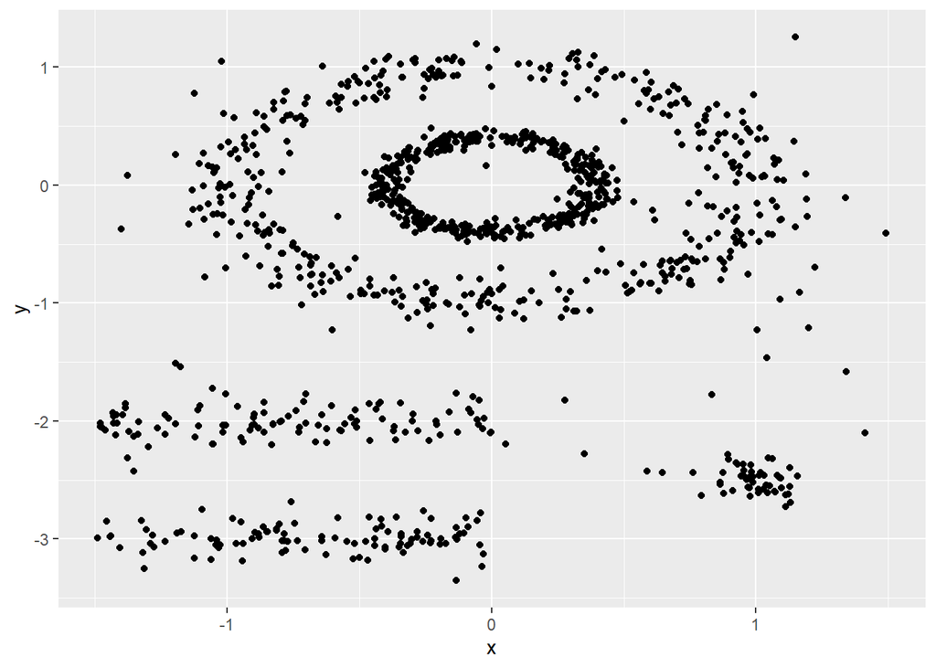

```r
# Plot the positions of the players and color them using their cluster
ggplot(Small_df, aes(x = x, y = y)) +
  geom_point()
```

Let’s see what K-means does with this data.

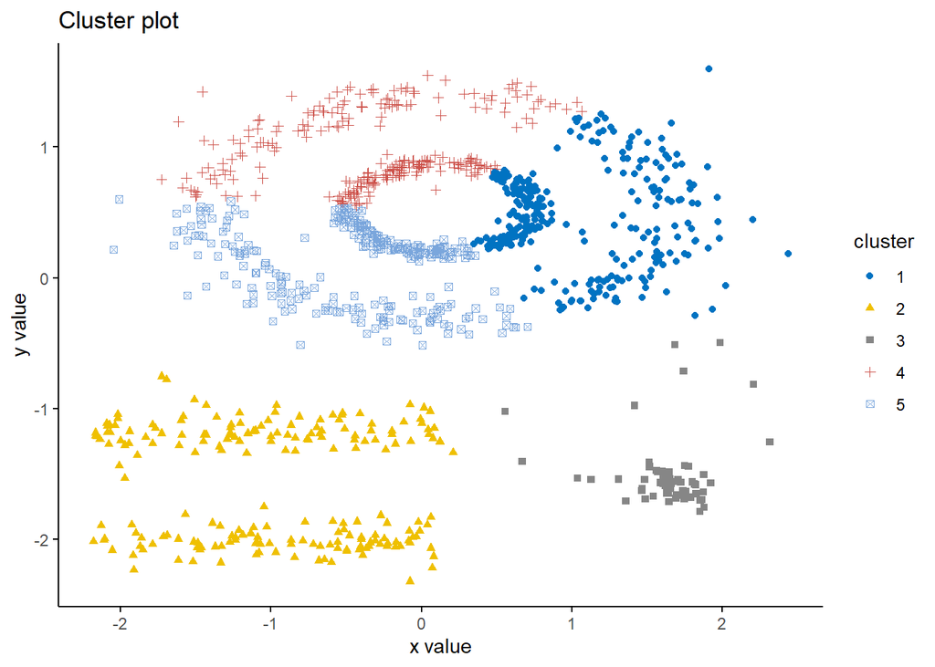

```r
set.seed(123)
km.res <- kmeans(Small_df, 5, nstart = 25)
fviz_cluster(km.res, Small_df,  geom = "point",
             ellipse= FALSE, show.clust.cent = FALSE,
             palette = "jco", ggtheme = theme_classic())
```

Not the five clusters we can see visually. Also since each point must be in a cluster, some of the points that appear to be noise are included. Other methods such DBSCAN work better on this type of data.

```r
library(dbscan)
```

```r
db <- dbscan(Small_df, eps = 0.15, minPts = 5)
```

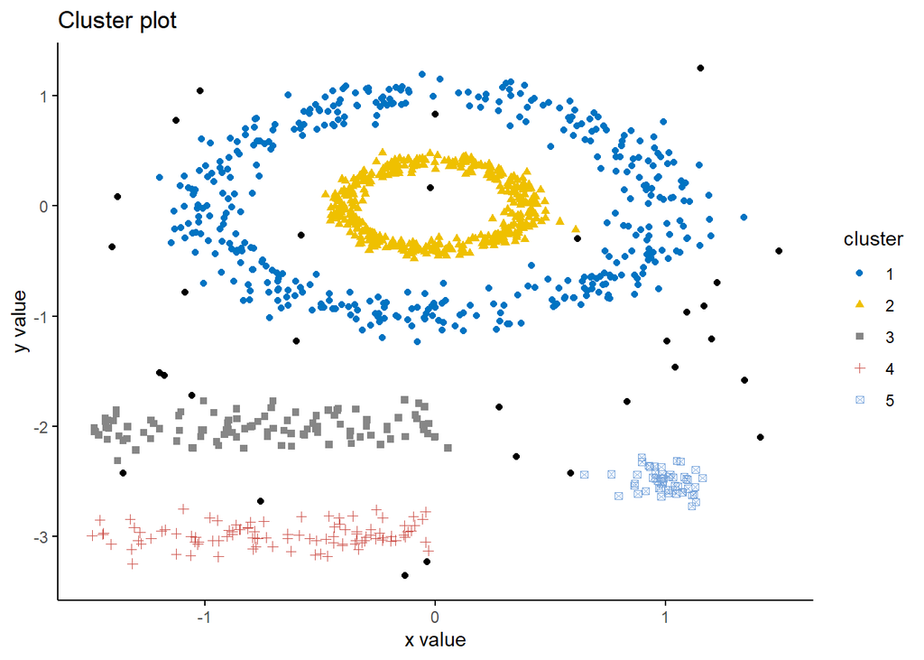

```r
# Plot DBSCAN results
fviz_cluster(db, data = Small_df, stand = FALSE,
             ellipse = FALSE, show.clust.cent = FALSE,
             geom = "point",palette = "jco", ggtheme = theme_classic())
```

### Curse of Dimensionality

In high dimension K-means is going to have problems because of the curse of dimensionality. Nothing will be near the centroids. A solution is spherical k-means.

# Homework

Use K-means to group the customers in the market segmenting data into the appropriate marketing groups.

```r
market_seg <- readRDS("ws_customers.rds")
market_seg
```

| Milk | Grocery | Frozen |
| --- | --- | --- |
| 11103 | 12469 | 902 |
| 2013 | 6550 | 909 |
| 1897 | 5234 | 417 |
| 1304 | 3643 | 3045 |
| 3199 | 6986 | 1455 |
| 4560 | 9965 | 934 |
| 879 | 2060 | 264 |
| 6243 | 6360 | 824 |
| 13316 | 20399 | 1809 |
| 5302 | 9785 | 364 |

[output cut: 35 more lines]